# Relatório pandemia e desemprego

## Resumo

O objetivo da pesquisa é explorar dados sobre desemprego durante a pandemia, se possível avaliando em termos quantitativos os efeitos do auxílio emergencial governamental para a população, frente a um momento histórico de crise sanitária mundial e crise política nacional. Também será avaliada a percepção das pessoas sobre as ações tomadas pelo governo para conter o avanço do COVID-19.

## Introdução

O ano de 2020 entra para história mundial como um período em que a humanidade enfrentou uma crise sanitária, econômica e social gerada pela pandemia do novo Coronavírus. Conforme o trabalho de Brandão (2020), esta situação globalizada desencadeou uma série de debates sobre como mitigar os efeitos econômicos e sociais da doença, assim como a necessidade do distanciamento social que reduziu a demanda da população, e consequentemente obteve um efeito negativo sobre o nível de emprego e de renda, além de reduzir investimentos, sobretudo privados.

## Metodologia

Trata-se de um estudo transversal realizado a partir de um questionário com quinze perguntas objetivas no formato de pesquisa de opinião, conforme normas da resolução 510/16 (MINISTÉRIO DA SAÚDE, 2016). Não foi necessário nenhum tipo de identificação dos respondentes e a participação foi voluntária. A investigação trata de questões referentes a emprego e desemprego durante a pandemia e para isso foi criado um questionário no Google Forms.

A pesquisa reuniu dados em meio ao universo da população do Estado do Rio de Janeiro, mais especificamente entre aqueles que deveriam estar inseridos na população economicamente ativa, seja locado no mercado de trabalho ou desempregados.

O questionário foi estruturado em quatro partes, para identificar o máximo de dados relacionados aos objetivos.

1. Questões referentes ao perfil socioeconômico dos respondentes, contendo as variáveis de sexo, idade, raça e faixa de renda.
2. Perguntas referentes ao isolamento e ao impacto dele na vida das pessoas.
3. Questões referentes às atitudes do Governo do Estado do Rio de Janeiro e do Governo Federal em relação ao isolamento social e à economia.
4. Sobre a inscrição no programa Federal da CAIXA, para o recebimento do Auxílio Emergencial do Governo Federal.

O instrumento de coleta foi construído na plataforma Formulários Google® e divulgado via internet, por meio dos aplicativos e redes sociais; whatsapp, instagram e facebook, entre os dias 2 e 8 de agosto de 2020. Ao todo, obtiveram-se 136 respostas de pessoas do Estado do Rio de Janeiro.

## Resultados

Inicialmente serão carregadas as bibliotecas usadas

```r
library(kableExtra)
library(stringr)
library(ggplot2)
library(psych)
library(dplyr)
library(rsconnect)
library(rmdformats)
```

Após carregar as bibliotecas, serão lidos os dados que estão em um CSV gerado pelo Google forms

```r
dados <- read.csv('Final.csv', encoding = 'UTF-8')
```

O estudo conta com uma amostra de `136` pessoas.

Como todas as tabelas de frequência irão seguir o mesmo padrão, será feita uma função para gerá-las.

```r
tabela <- function(freq_abs, title) {
  freq_rel <- prop.table(freq_abs)
  porcentagem <- freq_rel*100

  tabela <- cbind(c(freq_abs, sum(freq_abs)), round(x = c(freq_rel, sum(freq_rel)), digits = 2), c(str_c(round(x = porcentagem, digits = 2), '%'), str_c(round(x = sum(porcentagem), digits = 2),'%')))

  colnames(tabela) <-  c('Freq. Abs.', 'Freq. Rel.', 'Porcentagem')

  row.names(tabela)[dim(freq_abs)+1] <- 'Total'

  kable(tabela, caption = title, align = 'ccc') %>%
    kable_styling(bootstrap_options = c("striped", "hover", "condensed"), full_width = F)
}

tabela_a <- function(freq_abs, title) {
  freq_rel <- prop.table(freq_abs)
  porcentagem <- freq_rel*100
  acumulada <- cumsum(freq_abs)
  acumulada_rel <- prop.table(freq_abs) %>% cumsum()

  tabela <- cbind(c(freq_abs, sum(freq_abs)), round(x = c(freq_rel, sum(freq_rel)), digits = 2), c(str_c(round(x = porcentagem, digits = 2), '%'), str_c(round(x = sum(porcentagem), digits = 2),'%')), c(acumulada, ''), c(round(x = acumulada_rel, digits = 2), ''))

  colnames(tabela) <-  c('Freq. Abs.', 'Freq. Rel.', 'Porcentagem', 'Freq. Acum.', 'Freq. Acum. Rel.')

  row.names(tabela)[dim(freq_abs)+1] <- 'Total'

  kable(tabela, caption = title, align = 'ccc') %>%
    kable_styling(bootstrap_options = c("striped", "hover", "condensed"), full_width = F)
}

tabela_av <- function(freq_abs, title) {
  freq_rel <- prop.table(freq_abs)
  porcentagem <- freq_rel*100
  acumulada <- cumsum(freq_abs)
  acumulada_rel <- prop.table(freq_abs) %>% cumsum()

  tabela <- cbind(c(freq_abs, sum(freq_abs)), round(x = c(freq_rel, sum(freq_rel)), digits = 2), c(str_c(round(x = porcentagem, digits = 2), '%'), str_c(round(x = sum(porcentagem), digits = 2),'%')), c(acumulada, ''), c(round(x = acumulada_rel, digits = 2), ''))

  colnames(tabela) <-  c('Freq. Abs.', 'Freq. Rel.', 'Porcentagem', 'Freq. Acum.', 'Freq. Acum. Rel.')

  row.names(tabela) <- c("Péssimo", "Ruim", "Razoável", "Bom", "Excelente", "Total")

  #row.names(tabela)[dim(freq_abs)+1] <- 'Total'

  kable(tabela, caption = title, align = 'ccc') %>%
    kable_styling(bootstrap_options = c("striped", "hover", "condensed"), full_width = F)
}

#Correlação de duas variáveis
tabela_c_abs <- function(freq, title) {

  tabela <- rbind(freq, colSums(freq))
  tabela <- cbind(tabela, rowSums(freq))

  row.names(tabela)[dim(tabela)[1]] <- "Total"
  colnames(tabela)[dim(tabela)[2]] <- "Total"

  tabela[dim(tabela)[1],dim(tabela)[2]] <- sum(freq)

  kable(tabela, caption = title, align = 'ccc') %>%
    kable_styling(bootstrap_options = c("striped", "hover", "condensed"), full_width = F)
}
```

### Idade

Idade é uma variável quantitativa discreta, e por serem muitas idades diferentes, será dividida em intervalos.

```r
valores_idade <- describe(dados$idade)

sturges <- nclass.Sturges(dados$idade)
```

A tabela de frequência:

```r
tabela_a(table(cut(dados$idade, seq(valores_idade$min, valores_idade$max, l = sturges+1))), 'Distribuição por faixa etária')
```

Distribuição por faixa etária

|  | Freq. Abs. | Freq. Rel. | Porcentagem | Freq. Acum. | Freq. Acum. Rel. |
| --- | --- | --- | --- | --- | --- |
| (18,22.6] | 29 | 0.23 | 22.83% | 29 | 0.23 |
| (22.6,27.1] | 65 | 0.51 | 51.18% | 94 | 0.74 |
| (27.1,31.7] | 13 | 0.1 | 10.24% | 107 | 0.84 |
| (31.7,36.2] | 6 | 0.05 | 4.72% | 113 | 0.89 |
| (36.2,40.8] | 2 | 0.02 | 1.57% | 115 | 0.91 |
| (40.8,45.3] | 3 | 0.02 | 2.36% | 118 | 0.93 |
| (45.3,49.9] | 2 | 0.02 | 1.57% | 120 | 0.94 |
| (49.9,54.4] | 2 | 0.02 | 1.57% | 122 | 0.96 |
| (54.4,59] | 5 | 0.04 | 3.94% | 127 | 1 |
| Total | 127 | 1 | 100% |  |  |

Os valores da variável, como valores de medida central e de dispersão:

```r
kable(valores_idade, caption = "medidas", align = 'ccc') %>%
    kable_styling(bootstrap_options = c("striped", "hover", "condensed"), full_width = F)
```

medidas

|  | vars | n | mean | sd | median | trimmed | mad | min | max | range | skew | kurtosis | se |
| --- | --- | --- | --- | --- | --- | --- | --- | --- | --- | --- | --- | --- | --- |
| X1 | 1 | 136 | 26.96324 | 8.878946 | 25 | 25.16364 | 4.4478 | 18 | 59 | 41 | 2.113101 | 4.16138 | 0.7613633 |

O histograma com a distribuição por faixa etária:

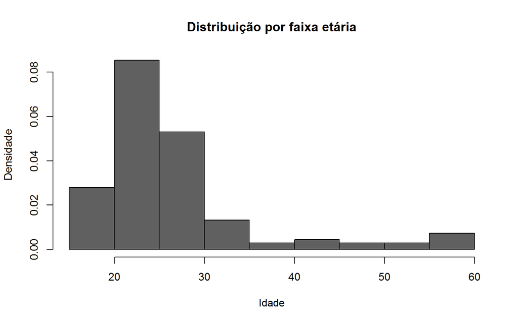

```r
hist(dados$idade, col = '#606060', freq = FALSE, ylab = 'Densidade', xlab = 'Idade', main = 'Distribuição por faixa etária')
```

### Sexo

Sexo é uma variável categórica nominal.

A tabela de frequência:

```r
tabela(table(dados$sexo), 'Distribuição por sexo')
```

Distribuição por sexo

|  | Freq. Abs. | Freq. Rel. | Porcentagem |
| --- | --- | --- | --- |
| Feminino | 76 | 0.56 | 55.88% |
| Masculino | 60 | 0.44 | 44.12% |
| Total | 136 | 1 | 100% |

Gráfico de barras com a distribuição da variável:

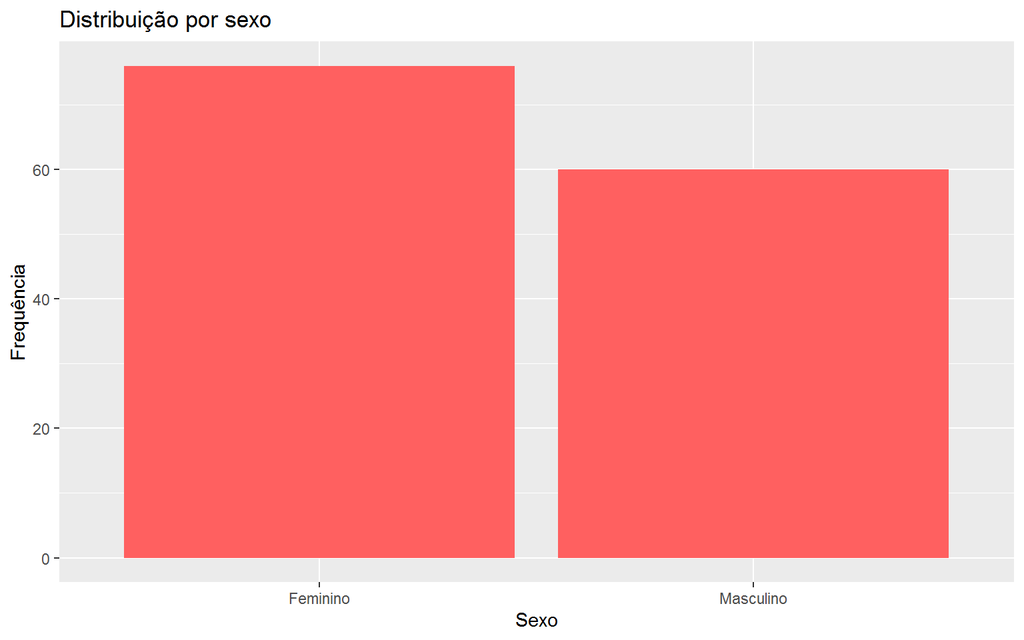

```r
sexo <- data.frame(label = row.names(table(dados$sexo)))

ggplot(sexo, aes(x = label, y = table(dados$sexo))) +
geom_col(fill = '#ff6060') + scale_fill_brewer(palette="Dark2") +
labs(title = "Distribuição por sexo",
     x = "Sexo",
     y = "Frequência")
```

### Raça

Raça é uma variável categórica nominal.

A tabela de frequência:

```r
tabela(table(dados$raca), 'Distribuição por raça')
```

Distribuição por raça

|  | Freq. Abs. | Freq. Rel. | Porcentagem |
| --- | --- | --- | --- |
| Amarela | 1 | 0.01 | 0.74% |
| Branca | 84 | 0.62 | 61.76% |
| Parda | 33 | 0.24 | 24.26% |
| Preta | 18 | 0.13 | 13.24% |
| Total | 136 | 1 | 100% |

Gráfico de barras com a distribuição da variável:

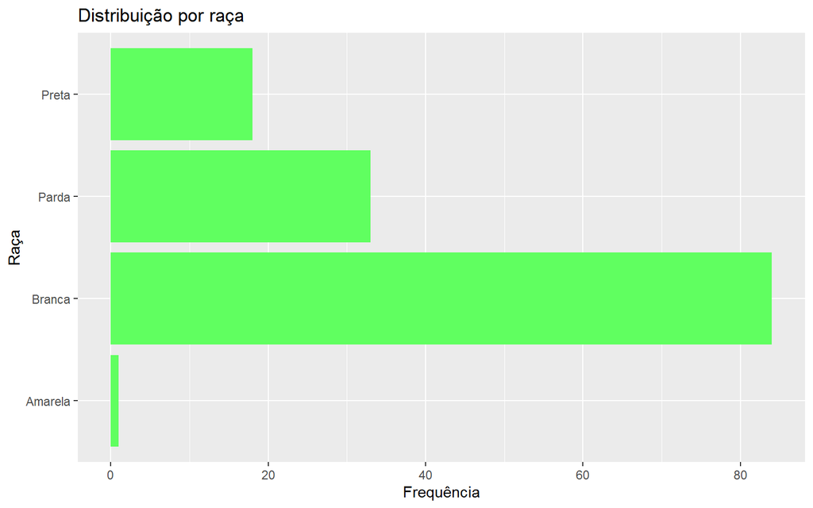

```r
raca <- data.frame(label = row.names(table(dados$raca)))

ggplot(raca, aes(x = label, y = table(dados$raca))) +
geom_col(fill = '#60ff60') +
labs(title = "Distribuição por raça",
     x = "Raça",
     y = "Frequência")+
  coord_flip()
```

### Perdeu o emprego?

A tabela de frequência:

```r
tabela(table(dados$perdeu_emprego), 'Distribuição por perda de emprego no período da pandemia')
```

Distribuição por perda de emprego no período da pandemia

|  | Freq. Abs. | Freq. Rel. | Porcentagem |
| --- | --- | --- | --- |
| Não | 112 | 0.82 | 82.35% |
| Prefiro não dizer | 2 | 0.01 | 1.47% |
| Sim | 22 | 0.16 | 16.18% |
| Total | 136 | 1 | 100% |

Gráfico de barras com a distribuição da variável:

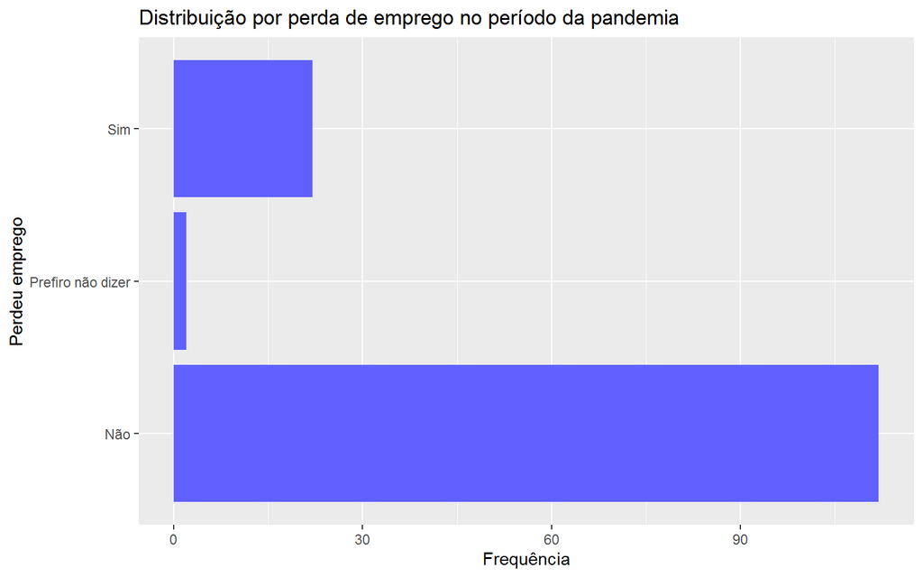

```r
perdeu_emprego <- data.frame(label = row.names(table(dados$perdeu_emprego)))

ggplot(perdeu_emprego, aes(x = label, y = table(dados$perdeu_emprego))) +
geom_col(fill = '#6060ff') +
labs(title = "Distribuição por perda de emprego no período da pandemia",
     x = "Perdeu emprego",
     y = "Frequência")+
  coord_flip()
```

### Motivo da perda do emprego

Essa pergunta está relacionada com as respostas da anterior, só podem ser consideradas as que responderam ‘Sim’ na pergunta anterior.  
Por isso é necessário limpar as possíveis incoerências:

```r
for(i in 1:dim(dados)[1]){
  if(dados$perdeu_emprego[i] != 'Sim') {
    dados$motivo[i] <- ''
  }
}
```

Após isso é possível construir as tabelas.

A tabela de frequência:

```r
tabela(table(dados$motivo, exclude = ''), 'Distribuição por motivo da demissão')
```

Distribuição por motivo da demissão

|  | Freq. Abs. | Freq. Rel. | Porcentagem |
| --- | --- | --- | --- |
| A direção da escola decidiu cancelar o contrato de todos, só manteve quem tinha carteira assinada. | 1 | 0.05 | 4.55% |
| Crise causada pela pandemia | 11 | 0.5 | 50% |
| Meu contrato foi suspenso e depois reduziram a carga horária | 1 | 0.05 | 4.55% |
| Motivos não relacionados com a pandemia | 2 | 0.09 | 9.09% |
| Não possibilidade de trabalhar remotamente | 3 | 0.14 | 13.64% |
| Tive minha bolsa de mestrado cancelada pelo governo | 1 | 0.05 | 4.55% |
| tive o contrato suspenso | 2 | 0.09 | 9.09% |
| tive que fechar minha loja | 1 | 0.05 | 4.55% |
| Total | 22 | 1 | 100% |

Gráfico de barras com a distribuição da variável:

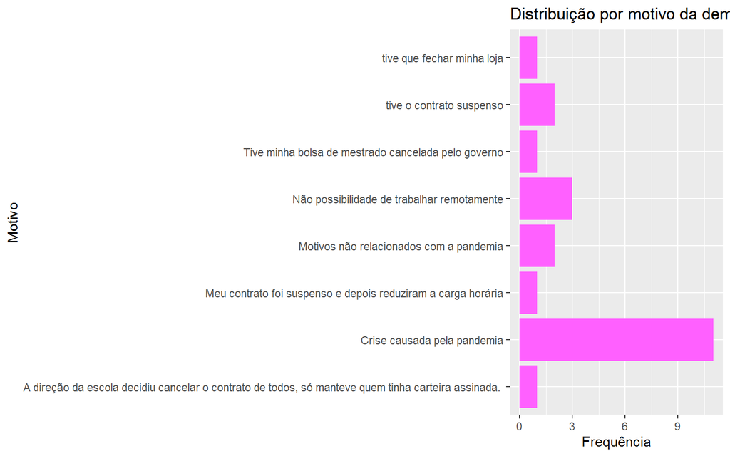

```r
motivo <- data.frame(label = row.names(table(dados$motivo, exclude = '')))

ggplot(motivo, aes(x = label, y = table(dados$motivo, exclude = ''))) +
geom_col(fill = '#ff60ff') +
labs(title = "Distribuição por motivo da demissão",
     x = "Motivo",
     y = "Frequência")+
  coord_flip()
```

### Fonte da renda

Essa pergunta aceita múltiplas respostas, logo o total não será necessariamente o tamanho da amostra e sim o total de respostas.

A tabela de frequêmcia:

```r
fonte <- dados$fonte_renda
tam <- length(fonte)
for(i in 1:tam) {
  if(grepl(';', fonte[i])) {
    result <- str_split(fonte[i], ';')
    for(j in 1:length(result[[1]])) {
      fonte <- c(fonte, result[[1]][j])
    }
    fonte[i] <- ''
  }
}

tabela(table(fonte, exclude = ''), 'Distribuição por fonte da renda')
```

Distribuição por fonte da renda

|  | Freq. Abs. | Freq. Rel. | Porcentagem |
| --- | --- | --- | --- |
| Aposentado | 3 | 0.02 | 2.03% |
| Autônomo | 23 | 0.16 | 15.54% |
| Bolsista Capes/CNPq | 12 | 0.08 | 8.11% |
| CLT | 36 | 0.24 | 24.32% |
| Desempregado | 17 | 0.11 | 11.49% |
| Estágio | 11 | 0.07 | 7.43% |
| Freelancer | 8 | 0.05 | 5.41% |
| Jovem aprendiz | 3 | 0.02 | 2.03% |
| Nunca trabalhou | 12 | 0.08 | 8.11% |
| Prefiro não dizer | 4 | 0.03 | 2.7% |
| Servidor Público | 10 | 0.07 | 6.76% |
| Tenho meu próprio negócio | 9 | 0.06 | 6.08% |
| Total | 148 | 1 | 100% |

O gráfico de barras com a distribuição da variável:

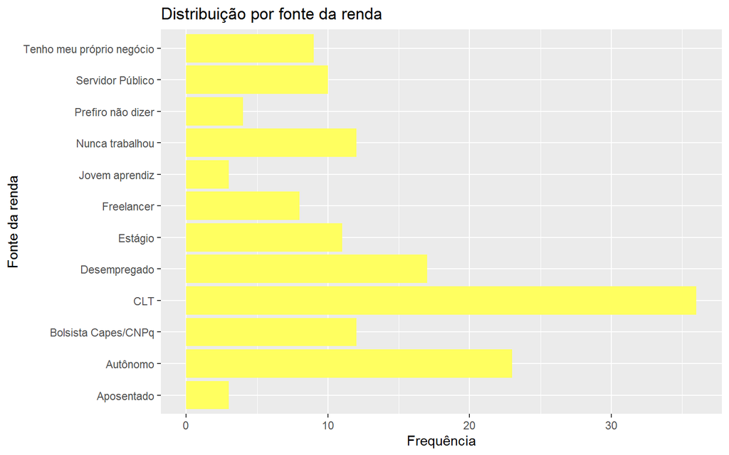

```r
fonte_renda <- data.frame(label = row.names(table(fonte, exclude = '')))

ggplot(fonte_renda, aes(x = label, y = table(fonte, exclude = ''))) +
geom_col(fill = '#ffff60') +
labs(title = "Distribuição por fonte da renda",
     x = "Fonte da renda",
     y = "Frequência")+
  coord_flip()
```

### Conhece alguém que perdeu o emprego na pandemia

Avalia se o entrevistado conhece alguém que perdeu o emprego durante o período de pandemia.

A tabela de frequência:

```r
tabela(table(dados$conhece), 'Distribuição por conhecimento de pessoas que perderam o emprego na pandemia')
```

Distribuição por conhecimento de pessoas que perderam o emprego na pandemia

|  | Freq. Abs. | Freq. Rel. | Porcentagem |
| --- | --- | --- | --- |
| Não | 22 | 0.16 | 16.18% |
| Sim | 114 | 0.84 | 83.82% |
| Total | 136 | 1 | 100% |

O gráfico de colunas com a distribuição da variável:

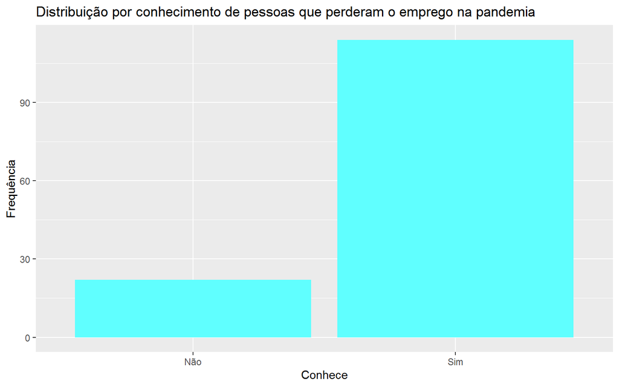

```r
conhece <- data.frame(label = row.names(table(dados$conhece)))

ggplot(conhece, aes(x = label, y = table(dados$conhece))) +
geom_col(fill = '#60ffff') +
labs(title = "Distribuição por conhecimento de pessoas que perderam o emprego na pandemia",
     x = "Conhece",
     y = "Frequência")
```

### Buscou o auxílio emergencial

Já com relação às pessoas que buscaram o auxílio emergencial.

A tabela de frequência:

```r
tabela(table(dados$auxilio), 'Distribuição por pessoas que buscaram o auxílio emergencial')
```

Distribuição por pessoas que buscaram o auxílio emergencial

|  | Freq. Abs. | Freq. Rel. | Porcentagem |
| --- | --- | --- | --- |
| Não | 87 | 0.64 | 63.97% |
| Prefiro não dizer | 4 | 0.03 | 2.94% |
| Sim | 45 | 0.33 | 33.09% |
| Total | 136 | 1 | 100% |

O gráfico de colunas com a distribuição da variável:

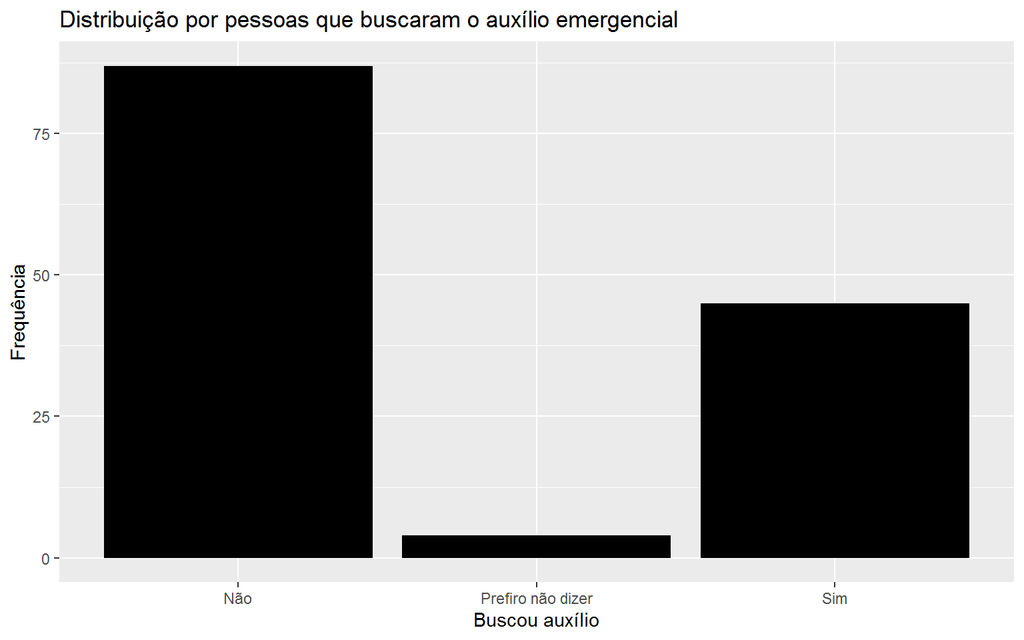

```r
auxilio <- data.frame(label = row.names(table(dados$auxilio)))

ggplot(auxilio, aes(x = label, y = table(dados$auxilio))) +
geom_col(fill = '#000000') +
labs(title = "Distribuição por pessoas que buscaram o auxílio emergencial",
     x = "Buscou auxílio",
     y = "Frequência")
```

### Renda mensal antes da pandemia

Essa pergunta está relacionada à renda mensal que o entrevistado tinha antes do período de pandemia começar.

Por ser uma variável ordinal, para fazer a frequência acumulada serão retirados os “Prefiro não dizer”.

A tabela de frequência:

```r
renda_antes <- dados$renda_antes

for(i in 1:length(renda_antes)) {
  if(renda_antes[i] == 'Menos de R$1045,00') {
    renda_antes[i] <- 'De R$0,00 até R$1045,00'
  }
}

tabela_a(table(renda_antes, exclude = 'Prefiro não dizer'), 'Distribuição por renda antes da pandemia')
```

Distribuição por renda antes da pandemia

|  | Freq. Abs. | Freq. Rel. | Porcentagem | Freq. Acum. | Freq. Acum. Rel. |
| --- | --- | --- | --- | --- | --- |
| De R$0,00 até R$1045,00 | 44 | 0.36 | 36.07% | 44 | 0.36 |
| De R$1.045,00 até R$3.135,00 | 36 | 0.3 | 29.51% | 80 | 0.66 |
| De R$3.135,00 até R$5.225,00 | 21 | 0.17 | 17.21% | 101 | 0.83 |
| De R$5.225,00 até R$7.315,00 | 7 | 0.06 | 5.74% | 108 | 0.89 |
| De R$7.315,00 até R$9.405,00 | 7 | 0.06 | 5.74% | 115 | 0.94 |
| Maior ou igual à de R$9.405,00 | 7 | 0.06 | 5.74% | 122 | 1 |
| Total | 122 | 1 | 100% |  |  |

O gráfico de barras com a distribuição da variável:

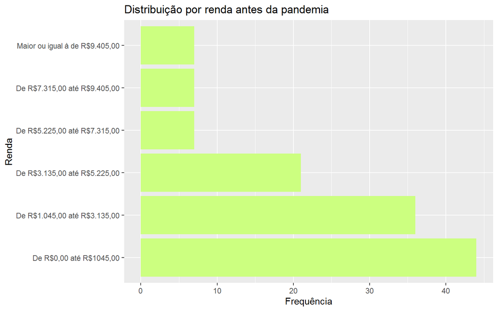

```r
renda_antes_d <- data.frame(label = row.names(table(renda_antes, exclude = 'Prefiro não dizer')))

ggplot(renda_antes_d, aes(x = label, y = table(renda_antes, exclude = 'Prefiro não dizer'))) +
geom_col(fill = '#ccff80') +
labs(title = "Distribuição por renda antes da pandemia",
     x = "Renda",
     y = "Frequência") +
  coord_flip()
```

### Renda mensal atual

Essa pergunta está relacionada à renda mensal que o entrevistado tem atualmente.

Por ser uma variável ordinal, para fazer a frequência acumulada serão retirados os “Prefiro não dizer”.

A tabela de frequência:

```r
renda_atual <- dados$renda_atual

for(i in 1:length(renda_atual)) {
  if(renda_atual[i] == 'Menos de R$1045,00') {
    renda_atual[i] <- 'De R$0,00 até R$1045,00'
  }
}

tabela_a(table(renda_atual, exclude = 'Prefiro não dizer'), 'Distribuição por renda mensal atual')
```

Distribuição por renda mensal atual

|  | Freq. Abs. | Freq. Rel. | Porcentagem | Freq. Acum. | Freq. Acum. Rel. |
| --- | --- | --- | --- | --- | --- |
| De R$0,00 até R$1045,00 | 47 | 0.39 | 38.52% | 47 | 0.39 |
| De R$1.045,00 até R$3.135,00 | 40 | 0.33 | 32.79% | 87 | 0.71 |
| De R$3.135,00 até R$5.225,00 | 17 | 0.14 | 13.93% | 104 | 0.85 |
| De R$5.225,00 até R$7.315,00 | 5 | 0.04 | 4.1% | 109 | 0.89 |
| De R$7.315,00 até R$9.405,00 | 7 | 0.06 | 5.74% | 116 | 0.95 |
| Maior ou igual à R$9.405,00 | 6 | 0.05 | 4.92% | 122 | 1 |
| Total | 122 | 1 | 100% |  |  |

O gráfico de barras com a distribuição da variável:

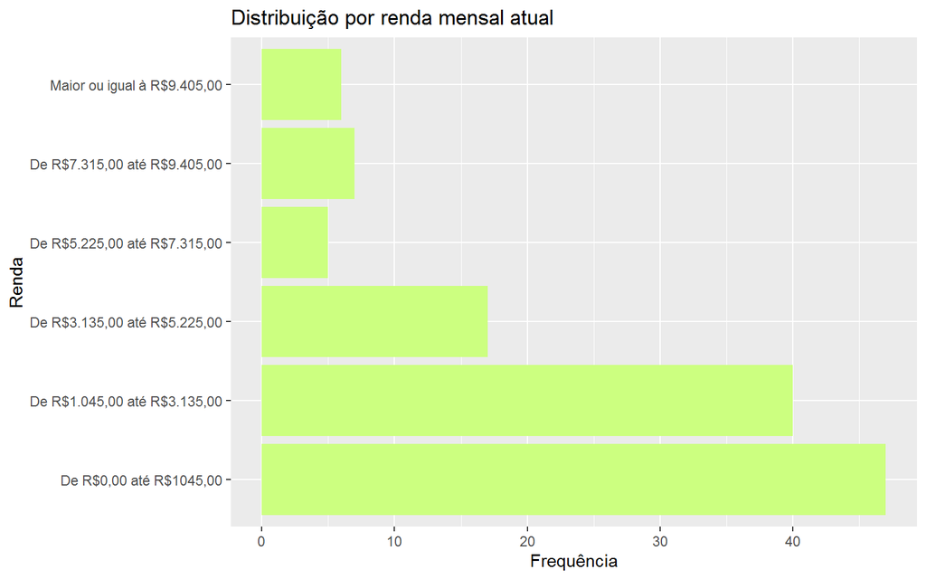

```r
renda_atual_d <- data.frame(label = row.names(table(renda_atual, exclude = 'Prefiro não dizer')))

ggplot(renda_atual_d, aes(x = label, y = table(renda_atual, exclude = 'Prefiro não dizer'))) +
geom_col(fill = '#ccff80') +
labs(title = "Distribuição por renda mensal atual",
     x = "Renda",
     y = "Frequência") +
  coord_flip()
```

### Saiu de casa durante a pandemia por causa do emprego

A tabela de frequência:

```r
saiu_emprego <- dados$saiu_emprego

# transformar nenhum em 0 para o table retornar já ordenado
for(i in 1:length(saiu_emprego)) {
  if(saiu_emprego[i] == 'Nenhum, trabalho de home office') {
    saiu_emprego[i] <- '0, trabalho de home office'
  }
}

tabela_a(table(saiu_emprego, exclude = c('', 'Prefiro não dizer')), 'Distribuição por saída de casa por causa do emprego')
```

Distribuição por saída de casa por causa do emprego

|  | Freq. Abs. | Freq. Rel. | Porcentagem | Freq. Acum. | Freq. Acum. Rel. |
| --- | --- | --- | --- | --- | --- |
| 0, trabalho de home office | 55 | 0.64 | 63.95% | 55 | 0.64 |
| de 1 a 5 dias | 8 | 0.09 | 9.3% | 63 | 0.73 |
| de 11 a 15 dias | 3 | 0.03 | 3.49% | 66 | 0.77 |
| de 16 a 20 dias | 3 | 0.03 | 3.49% | 69 | 0.8 |
| de 6 a 10 dias | 1 | 0.01 | 1.16% | 70 | 0.81 |
| Mais de 20 dias ou o mês inteiro | 16 | 0.19 | 18.6% | 86 | 1 |
| Total | 86 | 1 | 100% |  |  |

O gráfico de barras com a distribuição da variável:

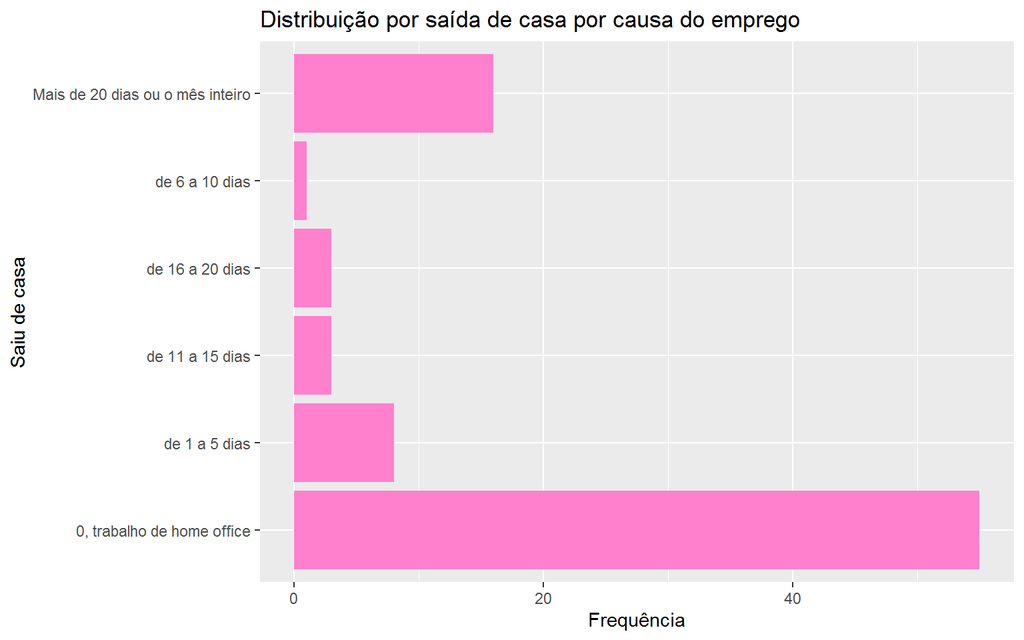

```r
saiu_emprego_d <- data.frame(label = row.names(table(saiu_emprego, exclude = c('', 'Prefiro não dizer'))))

ggplot(saiu_emprego_d, aes(x = label, y = table(saiu_emprego, exclude = c('', 'Prefiro não dizer')))) +
geom_col(fill = '#ff80cc') +
labs(title = "Distribuição por saída de casa por causa do emprego",
     x = "Saiu de casa",
     y = "Frequência")+
  coord_flip()
```

### Saiu de casa para procurar emprego ou buscar auxílio

A tabela de frequência:

```r
saiu_buscar_emprego <- dados$saiu_buscar_emprego

# transformar nenhum em 0 para o table retornar já ordenado
for(i in 1:length(saiu_buscar_emprego)) {
  if(saiu_buscar_emprego[i] == 'Nenhum') {
    saiu_buscar_emprego[i] <- '0'
  }
}

tabela_a(table(saiu_buscar_emprego, exclude = c('', 'Prefiro não dizer')), 'Distribuição por saída de casa para procurar emprego ou buscar auxílio')
```

Distribuição por saída de casa para procurar emprego ou buscar auxílio

|  | Freq. Abs. | Freq. Rel. | Porcentagem | Freq. Acum. | Freq. Acum. Rel. |
| --- | --- | --- | --- | --- | --- |
| 0 | 45 | 0.73 | 72.58% | 45 | 0.73 |
| de 1 a 5 dias | 10 | 0.16 | 16.13% | 55 | 0.89 |
| de 16 a 20 dias | 1 | 0.02 | 1.61% | 56 | 0.9 |
| de 6 a 10 dias | 4 | 0.06 | 6.45% | 60 | 0.97 |
| Mais de 20 dias ou o mês inteiro | 2 | 0.03 | 3.23% | 62 | 1 |
| Total | 62 | 1 | 100% |  |  |

O gráfico de barras com a distribuição da variável:

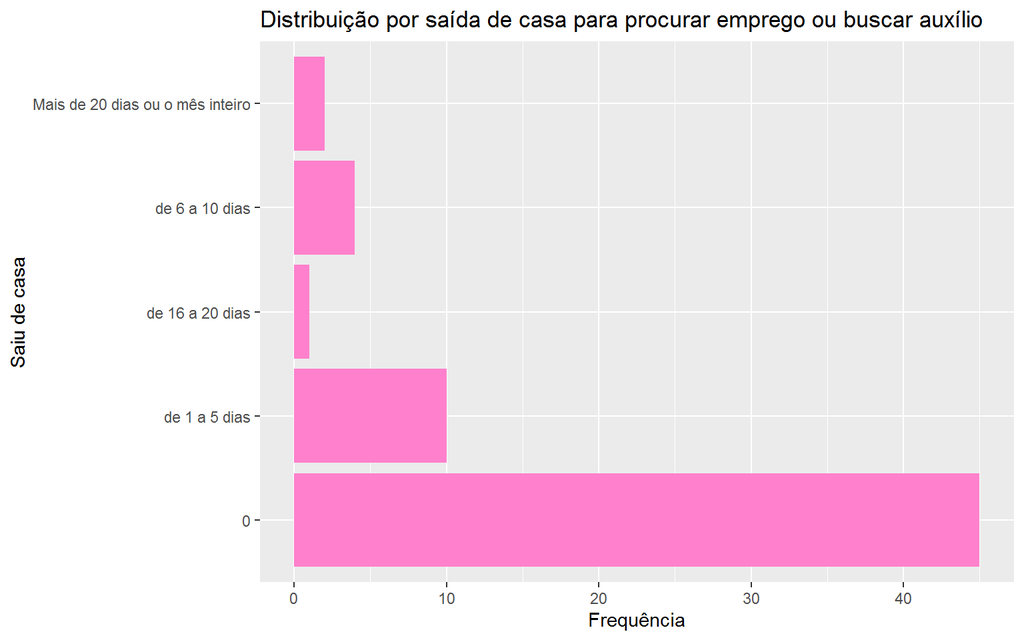

```r
saiu_buscar_emprego_d <- data.frame(label = row.names(table(saiu_buscar_emprego, exclude = c('', 'Prefiro não dizer'))))

ggplot(saiu_buscar_emprego_d, aes(x = label, y = table(saiu_buscar_emprego, exclude = c('', 'Prefiro não dizer')))) +
geom_col(fill = '#ff80cc') +
labs(title = "Distribuição por saída de casa para procurar emprego ou buscar auxílio",
     x = "Saiu de casa",
     y = "Frequência")+
  coord_flip()
```

### Avaliação do enfrentamento da crise pelo governo estadual

A tabela de frequência:

```r
tabela_av(table(dados$avaliacao_estadual_crise), 'Distribuição da avaliação do enfrentamento da crise pelo governo estadual')
```

Distribuição da avaliação do enfrentamento da crise pelo governo estadual

|  | Freq. Abs. | Freq. Rel. | Porcentagem | Freq. Acum. | Freq. Acum. Rel. |
| --- | --- | --- | --- | --- | --- |
| Péssimo | 55 | 0.4 | 40.44% | 55 | 0.4 |
| Ruim | 37 | 0.27 | 27.21% | 92 | 0.68 |
| Razoável | 31 | 0.23 | 22.79% | 123 | 0.9 |
| Bom | 10 | 0.07 | 7.35% | 133 | 0.98 |
| Excelente | 3 | 0.02 | 2.21% | 136 | 1 |
| Total | 136 | 1 | 100% |  |  |

O gráfico de barras com a distribuição da variável:

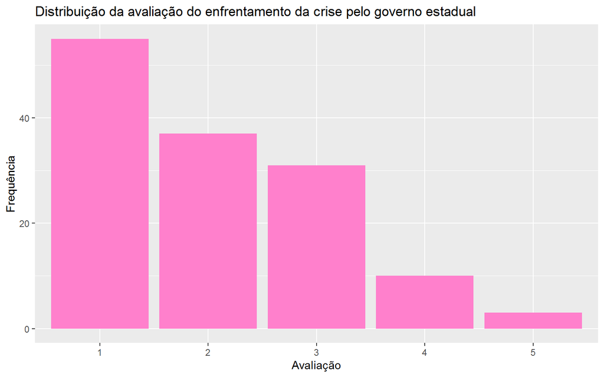

```r
av_est <- data.frame(label = row.names(table(dados$avaliacao_estadual_crise)))

ggplot(av_est, aes(x = label, y = table(dados$avaliacao_estadual_crise))) +
geom_col(fill = '#ff80cc') +
labs(title = "Distribuição da avaliação do enfrentamento da crise pelo governo estadual",
     x = "Avaliação",
     y = "Frequência")
```

### Avaliação do trabalho do governo federal com relação à economia

A tabela de frequência:

```r
tabela_av(table(dados$avaliacao_federal_economia), 'Distribuição da avaliação do trabalho do governo federal com relação à economia')
```

Distribuição da avaliação do trabalho do governo federal com relação à economia

|  | Freq. Abs. | Freq. Rel. | Porcentagem | Freq. Acum. | Freq. Acum. Rel. |
| --- | --- | --- | --- | --- | --- |
| Péssimo | 80 | 0.59 | 58.82% | 80 | 0.59 |
| Ruim | 28 | 0.21 | 20.59% | 108 | 0.79 |
| Razoável | 16 | 0.12 | 11.76% | 124 | 0.91 |
| Bom | 4 | 0.03 | 2.94% | 128 | 0.94 |
| Excelente | 8 | 0.06 | 5.88% | 136 | 1 |
| Total | 136 | 1 | 100% |  |  |

O gráfico de barras com a distribuição da variável:

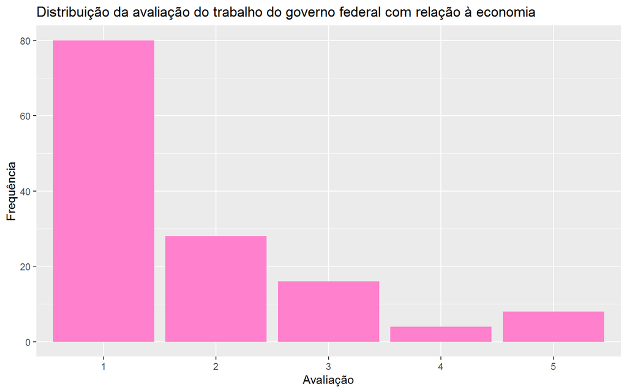

```r
av_fed_ec <- data.frame(label = row.names(table(dados$avaliacao_federal_economia)))

ggplot(av_fed_ec, aes(x = label, y = table(dados$avaliacao_federal_economia))) +
geom_col(fill = '#ff80cc') +
labs(title = "Distribuição da avaliação do trabalho do governo federal com relação à economia",
     x = "Avaliação",
     y = "Frequência")
```

### Avaliação do enfrentamento do governo federal com relação à pandemia

A tabela de frequência:

```r
tabela_av(table(dados$avaliacao_federal_pandemia), 'Distribuição da avaliação do enfrentamento do governo federal com relação à pandemia')
```

Distribuição da avaliação do enfrentamento do governo federal com relação à pandemia

|  | Freq. Abs. | Freq. Rel. | Porcentagem | Freq. Acum. | Freq. Acum. Rel. |
| --- | --- | --- | --- | --- | --- |
| Péssimo | 99 | 0.73 | 72.79% | 99 | 0.73 |
| Ruim | 20 | 0.15 | 14.71% | 119 | 0.88 |
| Razoável | 8 | 0.06 | 5.88% | 127 | 0.93 |
| Bom | 3 | 0.02 | 2.21% | 130 | 0.96 |
| Excelente | 6 | 0.04 | 4.41% | 136 | 1 |
| Total | 136 | 1 | 100% |  |  |

O gráfico de barras com a distribuição da variável:

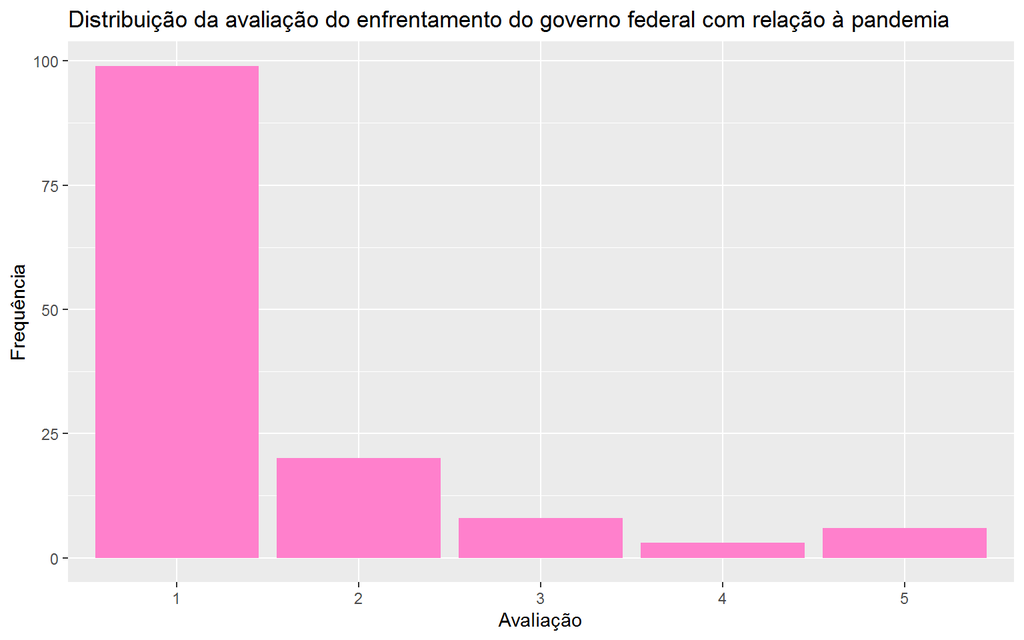

```r
av_fed <- data.frame(label = row.names(table(dados$avaliacao_federal_pandemia)))

ggplot(av_fed, aes(x = label, y = table(dados$avaliacao_federal_pandemia))) +
geom_col(fill = '#ff80cc') +
labs(title = "Distribuição da avaliação do enfrentamento do governo federal com relação à pandemia",
     x = "Avaliação",
     y = "Frequência")
```

### Relação de sexo com a perda do emprego

A tabela de contingência:

```r
tabela_c_abs(table(dados$sexo, dados$perdeu_emprego), 'Correlação de sexo com a perda do emprego')
```

Correlação de sexo com a perda do emprego

|  | Não | Prefiro não dizer | Sim | Total |
| --- | --- | --- | --- | --- |
| Feminino | 58 | 1 | 17 | 76 |
| Masculino | 54 | 1 | 5 | 60 |
| Total | 112 | 2 | 22 | 136 |

O gráfico de mosaico:

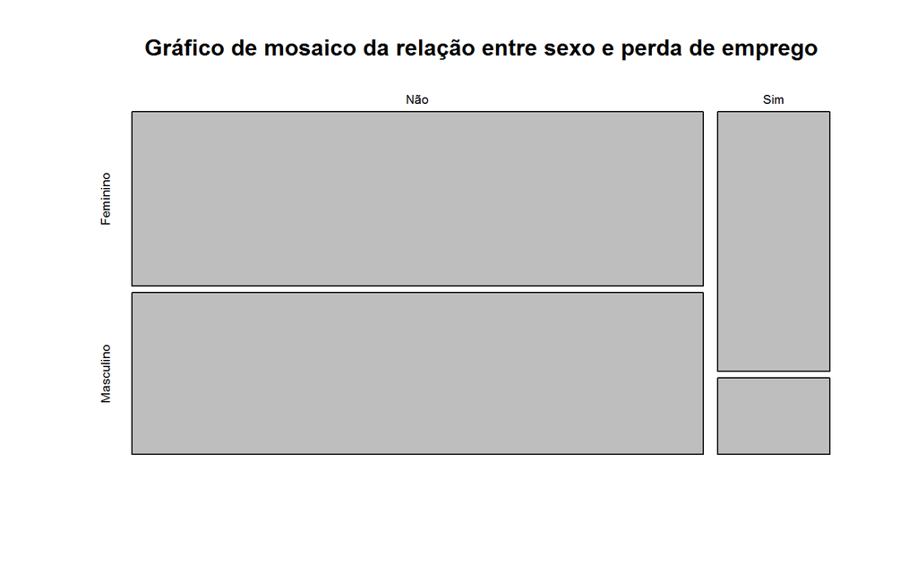

```r
mosaicplot(table(dados$perdeu_emprego, dados$sexo, exclude = 'Prefiro não dizer'), main = 'Gráfico de mosaico da relação entre sexo e perda de emprego')
```

### Relação de raça com a perda do emprego

A tabela de contingência:

```r
tabela_c_abs(table(dados$raca, dados$perdeu_emprego), 'Correlação de raça com a perda do emprego')
```

Correlação de raça com a perda do emprego

|  | Não | Prefiro não dizer | Sim | Total |
| --- | --- | --- | --- | --- |
| Amarela | 1 | 0 | 0 | 1 |
| Branca | 69 | 1 | 14 | 84 |
| Parda | 30 | 1 | 2 | 33 |
| Preta | 12 | 0 | 6 | 18 |
| Total | 112 | 2 | 22 | 136 |

[figure not shown]

```r
mosaicplot(table(dados$perdeu_emprego, dados$raca, exclude = 'Prefiro não dizer'), main = 'Gráfico de mosaico da relação entre sexo e perda de emprego')
```

## Conclusão

Como conclusão, este estudo nos forneceu algumas informações interessantes sobre emprego e desemprego durante a pandemia, considerando que os entrevistados residem no estado do RJ e a maioria deles tem entre 18 e 32 anos. Para citar algumas, temos que:

1. Boa parte dos entrevistados(84%) conhecem alguém que perdeu o emprego durante a pandemia.
2. Mais da metade dos empregados(64%) estão trabalhando de home office.
3. Muitos dos entrevistados não consideraram boas as ações dos governos federal e estadual para conter a pandemia e seus efeitos colaterais na economia.
4. As ações do governo federal apra conter a pandemia tiveram uma rejeição muito maior comparando com as do governo estadual
5. A maioria das pessoas que perderam emprego foram do sexo feminino.
6. Proporcionalmente, pessoas pretas perderam mais empregos do que pessoas de qualquer outra raça.

## Referencial Bibliográfico

BRANDÃO, Vinicius. O papel do Estado como garantidor de emprego e renda durante a pandemia do novo Coronavírus. **Thiago Antoniolli Resposta econômica à Pandemia do Covid-19: Análise do balanço setorial financeiro da economia**, p. 50.

MINISTÉRIO DA SAÚDE. Conselho Nacional de Saúde. Resolução nº 510, de 7 de abril de 2016. Dispõe sobre as normas aplicáveis a pesquisas em Ciências Humanas e Sociais. *Diário Oficial da União* 2016.